# Comparing BiLSTM and ABC Calibration for SIR Models

Utah COVID-19 Case Prediction with Uncertainty Quantification

Author

Sima Najafzadehkhoei

Published

December 12, 2025

## Introduction

This analysis compares two approaches to epidemic model calibration:

1. **BiLSTM (Deep Learning)**: Fast neural network-based parameter estimation
2. **ABC (Approximate Bayesian Computation)**: Simulation-based Bayesian inference

Both methods calibrate SIR model parameters from observed COVID-19 incidence data, but differ dramatically in computational cost and uncertainty quantification.

### Workflow Overview

1. Download recent COVID-19 case data from Utah (61 days)
2. **BiLSTM calibration**: Estimate parameters using trained neural network
3. **ABC calibration**: Estimate parameters using MCMC with 50% burn-in
4. Run 2,000 stochastic SIR simulations for each method
5. Compare predictions, uncertainty, and computational time

## Setup

```r
suppressPackageStartupMessages({
  library(tidyverse)
  library(ggplot2)
  library(epiworldR)
  library(epiworldRcalibrate)
  library(tictoc)
  library(data.table)
  library(knitr)
})
```

## Data Acquisition

### Load Packaged Data

```r
data("utah_covid_data")

# Preview the data
head(utah_covid_data)
```

```
        Date Daily.Cases X3.Day.Moving.Average Smoothed.3.Day.Moving.Average
1 2024-05-07          34                  0.91                          0.84
2 2024-05-08          27                  0.97                          0.86
3 2024-05-09          30                  0.93                          0.87
4 2024-05-10          24                  0.83                          0.88
5 2024-05-11          22                  0.78                          0.89
6 2024-05-12          14                  0.62                          0.91
             Status
1 Incidence Plateau
2 Incidence Plateau
3 Incidence Plateau
4 Incidence Plateau
5 Incidence Plateau
6 Incidence Plateau
```

```r
summary(utah_covid_data)
```

```
      Date             Daily.Cases     X3.Day.Moving.Average
 Min.   :2024-05-07   Min.   : 14.00   Min.   :0.620
 1st Qu.:2024-08-06   1st Qu.: 39.00   1st Qu.:1.260
 Median :2024-11-05   Median : 54.00   Median :1.770
 Mean   :2024-11-05   Mean   : 74.22   Mean   :2.283
 3rd Qu.:2025-02-04   3rd Qu.: 97.00   3rd Qu.:2.920
 Max.   :2025-05-06   Max.   :367.00   Max.   :6.970
 Smoothed.3.Day.Moving.Average    Status
 Min.   :0.780                 Length:365
 1st Qu.:1.420                 Class :character
 Median :1.900                 Mode  :character
 Mean   :2.282
 3rd Qu.:2.860
 Max.   :4.960
```

### Load Recent Case Data

```r
get_covid_data <- function(n_days) {

  # Use packaged data
  covid_data <- utah_covid_data

  # Filter to last n_days
  last_date <- max(covid_data$Date, na.rm = TRUE)
  covid_data <- subset(covid_data, Date > (last_date - n_days)) %>%
    dplyr::arrange(Date)

  stopifnot("Daily.Cases" %in% names(covid_data))
  covid_data
}

n_days <- 61
covid_data <- get_covid_data(n_days)
incidence <- covid_data$Daily.Cases
incidence_vec <- incidence

stopifnot(length(incidence) == n_days)

cat("Date range:", as.character(min(covid_data$Date)), "to",
    as.character(max(covid_data$Date)), "\n")
```

```
Date range: 2025-03-07 to 2025-05-06
```

```r
cat("Total cases observed:", sum(incidence), "\n")
```

```
Total cases observed: 2034
```

```r
cat("Mean daily cases:", round(mean(incidence), 1), "\n")
```

```
Mean daily cases: 33.3
```

### Configuration

```r
N     <- 50000      # Population size
recov <- 1 / 7     # Recovery rate (7-day infectious period)
model_ndays <- 60  # Simulation days
```

## Method 1: BiLSTM Calibration

### Parameter Estimation

```r
cat("=== BiLSTM Calibration ===\n")
```

```
=== BiLSTM Calibration ===
```

```r
tic("BiLSTM calibration")
lstm_predictions <- calibrate_sir(
  daily_cases = incidence_vec,
  population_size = N,
  recovery_rate = recov
)
```

```
BiLSTM model loaded successfully.
```

```r
bilstm_time <- toc()
```

```
BiLSTM calibration: 4.378 sec elapsed
```

```r
cat("\nCalibrated Parameters:\n")
```

```
Calibrated Parameters:
```

```r
print(lstm_predictions)
```

```
     ptran      crate         R0
0.02601591 6.11619061 1.11382782
```

### Stochastic Simulations (BiLSTM)

```r
cat("\n=== Running 2,000 Stochastic Simulations (BiLSTM) ===\n")
```

```
=== Running 2,000 Stochastic Simulations (BiLSTM) ===
```

```r
init_infected <- incidence[1]
prev <- init_infected / N

bilstm_model <- ModelSIRCONN(
  name              = "BiLSTM SIR",
  n                 = N,
  prevalence        = prev,
  contact_rate      = lstm_predictions[["crate"]],
  transmission_rate = lstm_predictions[["ptran"]],
  recovery_rate     = recov
)

saver_bilstm <- make_saver("transition")

tic("BiLSTM simulations")
run_multiple(
  bilstm_model,
  ndays    = model_ndays,
  nsims    = 2000,
  saver    = saver_bilstm,
  nthreads = 8
)
```

```
Starting multiple runs (2000) using 8 thread(s)
_________________________________________________________________________
_________________________________________________________________________
||||||||||||||||||||||||||||||||||||||||||||||||||||||||||||||||||||||||| done.
```

```r
bilstm_sim_time <- toc()
```

```
BiLSTM simulations: 45.138 sec elapsed
```

```r
bilstm_results <- run_multiple_get_results(
  bilstm_model,
  nthreads = 8,
  freader = data.table::fread
)
```

### Extract BiLSTM Confidence Intervals

```r
bilstm_transitions <- bilstm_results$transition %>%
  filter(from == "Susceptible", to == "Infected") %>%
  arrange(sim_num, date)

bilstm_quantiles <- bilstm_transitions %>%
  group_by(date) %>%
  summarize(
    lower_ci = quantile(counts, 0.025),
    upper_ci = quantile(counts, 0.975),
    median   = quantile(counts, 0.5),
    mean     = mean(counts),
    .groups  = "drop"
  )
```

## Method 2: ABC Calibration

### ABC Helper Functions

```r
model_seed <- 122

simulate_epidemic_calib <- function(params, ndays = model_ndays, seed = NULL) {
  if (!is.null(seed)) set.seed(seed)

  sim_model <- ModelSIRCONN(
    name="sim",
    n                 = as.integer(params[1]),
    prevalence        = as.numeric(params[2]),
    contact_rate      = as.numeric(params[3]),
    transmission_rate = as.numeric(params[5]),
    recovery_rate     = as.numeric(params[4])
  )

  verbose_off(sim_model)
  run(sim_model, ndays = ndays)

  counts <- get_hist_total(sim_model)
  infected_counts <- counts[counts$state == "Infected", "counts"]

  return(infected_counts)
}

simulation_fun <- function(params, lfmcmc_obj, observed_data_info) {
  sim_params <- c(
    observed_data_info$n,
    observed_data_info$preval,
    params[1],  # contact_rate
    params[2],  # recovery_rate
    params[3]   # transmission_prob
  )

  infected_counts <- simulate_epidemic_calib(sim_params, ndays = model_ndays)
  return(as.numeric(infected_counts))
}

summary_fun <- function(data, lfmcmc_obj) {
  return(as.numeric(data))
}

proposal_fun <- function(old_params, lfmcmc_obj) {
  new_crate <- old_params[1] * exp(rnorm(1, sd = 0.1))
  new_recov <- plogis(qlogis(old_params[2]) + rnorm(1, sd = 0.1))
  new_ptran <- plogis(qlogis(old_params[3]) + rnorm(1, sd = 0.1))

  return(c(new_crate, new_recov, new_ptran))
}

kernel_fun <- function(simulated_stat, observed_stat, epsilon, lfmcmc_obj) {
  diff <- sum((simulated_stat - observed_stat)^2)
  return(exp(-diff / (2 * epsilon^2)))
}
```

### Run ABC Calibration

```r
cat("\n=== ABC Calibration ===\n")
```

```
=== ABC Calibration ===
```

```r
initial_infected <- incidence_vec[1]
initial_prevalence <- initial_infected / N

observed_data_info <- list(
  n = N,
  preval = initial_prevalence
)

dummy_model <- ModelSIRCONN(
  name              = "dummy",
  n                 = as.integer(N),
  prevalence        = 0.1,
  contact_rate      = 5.0,
  transmission_rate = 0.1,
  recovery_rate     = 0.1
)

local_simulation_fun <- function(params, lfmcmc_obj) {
  return(simulation_fun(params, lfmcmc_obj, observed_data_info))
}

lfmcmc_obj <- LFMCMC(dummy_model)
lfmcmc_obj <- set_simulation_fun(lfmcmc_obj, local_simulation_fun)
lfmcmc_obj <- set_summary_fun(lfmcmc_obj, summary_fun)
lfmcmc_obj <- set_proposal_fun(lfmcmc_obj, proposal_fun)
lfmcmc_obj <- set_kernel_fun(lfmcmc_obj, kernel_fun)
lfmcmc_obj <- set_observed_data(lfmcmc_obj, incidence_vec)

init_params <- c(5, 1/7, 0.0571)
n_samples_calib <- 3000
burnin <- 1500
epsilon <- sqrt(sum(incidence_vec^2)) * 0.05

cat("Running LFMCMC with", n_samples_calib, "samples (50% burn-in)...\n")
```

```
Running LFMCMC with 3000 samples (50% burn-in)...
```

```r
tic("ABC calibration")
run_lfmcmc(
  lfmcmc = lfmcmc_obj,
  params_init = init_params,
  n_samples = n_samples_calib,
  epsilon = epsilon,
  seed = model_seed
)
```

```
_________________________________________________________________________
||||||||||||||||||||||||||||||||||||||||||||||||||||||||||||||||||||||||
```

```r
abc_time <- toc()
```

```
ABC calibration: 658.183 sec elapsed
```

```r
accepted <- get_all_accepted_params(lfmcmc_obj)
post_burnin <- tail(accepted, n = (n_samples_calib - burnin))

abc_median <- apply(post_burnin, 2, median)
abc_lower <- apply(post_burnin, 2, quantile, probs = 0.025)
abc_upper <- apply(post_burnin, 2, quantile, probs = 0.975)

abc_crate <- abc_median[1]
abc_recov <- abc_median[2]
abc_ptran <- abc_median[3]
abc_R0 <- (abc_crate * abc_ptran) / abc_recov

cat("\nCalibrated Parameters (Median with 95% CI):\n")
```

```
Calibrated Parameters (Median with 95% CI):
```

```r
cat("Contact Rate:", round(abc_crate, 4),
    "[", round(abc_lower[1], 4), ",", round(abc_upper[1], 4), "]\n")
```

```
Contact Rate: 1.9232 [ 0.9051 , 3.3907 ]
```

```r
cat("Recovery Rate:", round(abc_recov, 4),
    "[", round(abc_lower[2], 4), ",", round(abc_upper[2], 4), "]\n")
```

```
Recovery Rate: 0.0298 [ 0.0205 , 0.0958 ]
```

```r
cat("Transmission Prob:", round(abc_ptran, 4),
    "[", round(abc_lower[3], 4), ",", round(abc_upper[3], 4), "]\n")
```

```
Transmission Prob: 0.0101 [ 0.0051 , 0.0235 ]
```

```r
cat("R0:", round(abc_R0, 4), "\n")
```

```
R0: 0.6505
```

### Stochastic Simulations (ABC)

```r
cat("\n=== Running 2,000 Stochastic Simulations (ABC) ===\n")
```

```
=== Running 2,000 Stochastic Simulations (ABC) ===
```

```r
abc_model <- ModelSIRCONN(
  name              = "ABC SIR",
  n                 = N,
  prevalence        = initial_prevalence,
  contact_rate      = abc_crate,
  transmission_rate = abc_ptran,
  recovery_rate     = abc_recov
)

saver_abc <- make_saver("transition")

tic("ABC simulations")
run_multiple(
  abc_model,
  ndays    = model_ndays,
  nsims    = 2000,
  saver    = saver_abc,
  nthreads = 8
)
```

```
Starting multiple runs (2000) using 8 thread(s)
_________________________________________________________________________
_________________________________________________________________________
||||||||||||||||||||||||||||||||||||||||||||||||||||||||||||||||||||||||| done.
```

```r
abc_sim_time <- toc()
```

```
ABC simulations: 43.805 sec elapsed
```

```r
abc_sim_results <- run_multiple_get_results(
  abc_model,
  nthreads = 8,
  freader = data.table::fread
)
```

### Extract ABC Confidence Intervals

```r
abc_transitions <- abc_sim_results$transition %>%
  filter(from == "Susceptible", to == "Infected") %>%
  arrange(sim_num, date)

abc_quantiles <- abc_transitions %>%
  group_by(date) %>%
  summarize(
    lower_ci = quantile(counts, 0.025),
    upper_ci = quantile(counts, 0.975),
    median   = quantile(counts, 0.5),
    mean     = mean(counts),
    .groups  = "drop"
  )
```

## Comparison

### Timing Summary

```r
bilstm_total_mins <- (bilstm_time$toc - bilstm_time$tic) / 60
abc_total_mins <- (abc_time$toc - abc_time$tic) / 60
speedup <- abc_total_mins / bilstm_total_mins

cat("=== Computational Time Comparison ===\n\n")
```

```
=== Computational Time Comparison ===
```

```r
cat("BiLSTM calibration:", round(bilstm_total_mins, 2), "minutes\n")
```

```
BiLSTM calibration: 0.07 minutes
```

```r
cat("ABC calibration:", round(abc_total_mins, 2), "minutes\n")
```

```
ABC calibration: 10.97 minutes
```

```r
cat("\nSpeedup: BiLSTM is", round(speedup, 1), "x FASTER than ABC\n")
```

```
Speedup: BiLSTM is 150.3 x FASTER than ABC
```

### Parameter Comparison

```r
comparison_df <- data.frame(
  Parameter = c("Contact Rate", "Recovery Rate", "Trans. Prob", "R0"),
  BiLSTM = c(
    lstm_predictions[["crate"]],
    recov,
    lstm_predictions[["ptran"]],
    lstm_predictions[["R0"]]
  ),
  ABC = c(abc_crate, abc_recov, abc_ptran, abc_R0),
  Difference = c(
    lstm_predictions[["crate"]] - abc_crate,
    recov - abc_recov,
    lstm_predictions[["ptran"]] - abc_ptran,
    lstm_predictions[["R0"]] - abc_R0
  ),
  Pct_Diff = c(
    (lstm_predictions[["crate"]] - abc_crate) / abc_crate * 100,
    (recov - abc_recov) / abc_recov * 100,
    (lstm_predictions[["ptran"]] - abc_ptran) / abc_ptran * 100,
    (lstm_predictions[["R0"]] - abc_R0) / abc_R0 * 100
  )
)

knitr::kable(comparison_df, digits = 4,
             caption = "Parameter Estimates: BiLSTM vs ABC")
```

Parameter Estimates: BiLSTM vs ABC

| Parameter | BiLSTM | ABC | Difference | Pct_Diff |
| --- | --- | --- | --- | --- |
| Contact Rate | 6.1162 | 1.9232 | 4.1930 | 218.0285 |
| Recovery Rate | 0.1429 | 0.0298 | 0.1131 | 379.3617 |
| Trans. Prob | 0.0260 | 0.0101 | 0.0159 | 158.1001 |
| R0 | 1.1138 | 0.6505 | 0.4634 | 71.2343 |

### Combined Visualization

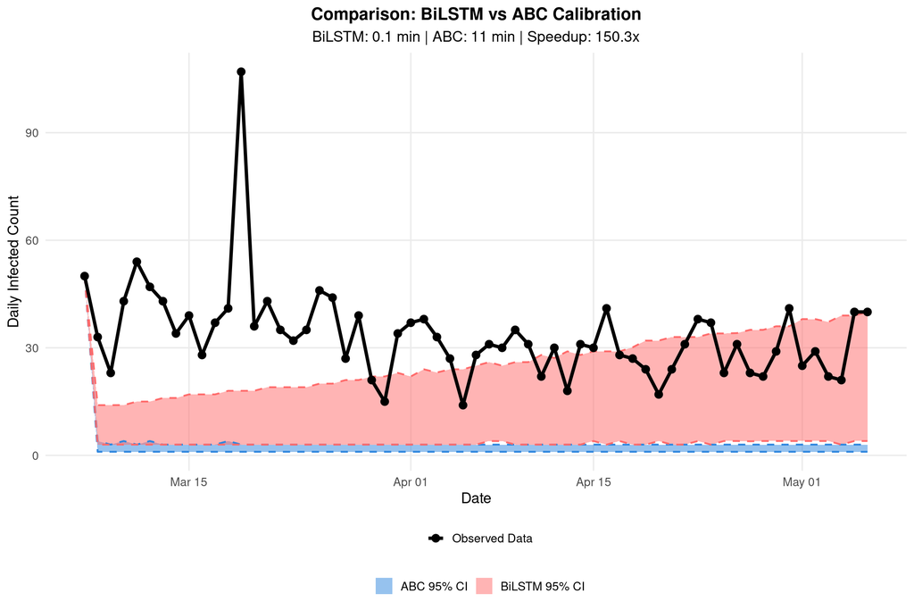

```r
# Prepare data
plot_df <- data.frame(
  Date = covid_data$Date,
  Observed = incidence,
  BiLSTM_median = bilstm_quantiles$median,
  BiLSTM_lower = bilstm_quantiles$lower_ci,
  BiLSTM_upper = bilstm_quantiles$upper_ci,
  ABC_median = abc_quantiles$median,
  ABC_lower = abc_quantiles$lower_ci,
  ABC_upper = abc_quantiles$upper_ci
)

# Main comparison plot with distinct colors and boundary lines
p_comparison <- ggplot(plot_df, aes(x = Date)) +
  # ABC CI ribbon (bright blue)
  geom_ribbon(
    aes(ymin = ABC_lower, ymax = ABC_upper, fill = "ABC 95% CI"),
    alpha = 0.5
  ) +
  # BiLSTM CI ribbon (bright coral/red)
  geom_ribbon(
    aes(ymin = BiLSTM_lower, ymax = BiLSTM_upper, fill = "BiLSTM 95% CI"),
    alpha = 0.5
  ) +
  # ABC boundary lines (dashed blue)
  geom_line(
    aes(y = ABC_lower),
    color = "#2E86DE",
    linetype = "dashed",
    linewidth = 0.8
  ) +
  geom_line(
    aes(y = ABC_upper),
    color = "#2E86DE",
    linetype = "dashed",
    linewidth = 0.8
  ) +
  # BiLSTM boundary lines (dashed red)
  geom_line(
    aes(y = BiLSTM_lower),
    color = "#FF6B6B",
    linetype = "dashed",
    linewidth = 0.8
  ) +
  geom_line(
    aes(y = BiLSTM_upper),
    color = "#FF6B6B",
    linetype = "dashed",
    linewidth = 0.8
  ) +
  # Observed data (thick black line and points)
  geom_line(
    aes(y = Observed, color = "Observed"),
    linewidth = 1.5
  ) +
  geom_point(
    aes(y = Observed, color = "Observed"),
    size = 3
  ) +
  scale_color_manual(
    name = "",
    values = c("Observed" = "black"),
    labels = c("Observed Data")
  ) +
  scale_fill_manual(
    name = "",
    values = c(
      "ABC 95% CI" = "#2E86DE",      # Bright blue
      "BiLSTM 95% CI" = "#FF6B6B"    # Bright coral/red
    ),
    labels = c("ABC 95% CI", "BiLSTM 95% CI")
  ) +
  labs(
    title = "Comparison: BiLSTM vs ABC Calibration",
    subtitle = paste0(
      "BiLSTM: ", round(bilstm_total_mins, 1), " min | ",
      "ABC: ", round(abc_total_mins, 1), " min | ",
      "Speedup: ", round(speedup, 1), "x"
    ),
    x = "Date",
    y = "Daily Infected Count"
  ) +
  theme_minimal(base_size = 14) +
  theme(
    legend.position = "bottom",
    plot.title = element_text(size = 16, face = "bold", hjust = 0.5),
    plot.subtitle = element_text(hjust = 0.5),
    legend.box = "vertical",
    panel.grid.minor = element_blank()
  ) +
  guides(
    color = guide_legend(order = 1),
    fill = guide_legend(order = 2)
  )

print(p_comparison)
```

### Model Performance

```r
# BiLSTM metrics
bilstm_coverage <- plot_df %>%
  mutate(in_ci = Observed >= BiLSTM_lower & Observed <= BiLSTM_upper) %>%
  summarize(coverage = mean(in_ci) * 100) %>%
  pull(coverage)

bilstm_rmse <- sqrt(mean((plot_df$BiLSTM_median - plot_df$Observed)^2))
bilstm_mae <- mean(abs(plot_df$BiLSTM_median - plot_df$Observed))

# ABC metrics
abc_coverage <- plot_df %>%
  mutate(in_ci = Observed >= ABC_lower & Observed <= ABC_upper) %>%
  summarize(coverage = mean(in_ci) * 100) %>%
  pull(coverage)

abc_rmse <- sqrt(mean((plot_df$ABC_median - plot_df$Observed)^2))
abc_mae <- mean(abs(plot_df$ABC_median - plot_df$Observed))

# Create comparison table
metrics_df <- data.frame(
  Metric = c("95% CI Coverage (%)", "RMSE", "MAE", "Time (Minutes)"),
  BiLSTM = c(
    round(bilstm_coverage, 1),
    round(bilstm_rmse, 2),
    round(bilstm_mae, 2),
    round(bilstm_total_mins, 2)
  ),
  ABC = c(
    round(abc_coverage, 1),
    round(abc_rmse, 2),
    round(abc_mae, 2),
    round(abc_total_mins, 2)
  )
)

knitr::kable(metrics_df,
             caption = "Model Performance Comparison")
```

Model Performance Comparison

| Metric | BiLSTM | ABC |
| --- | --- | --- |
| 95% CI Coverage (%) | 36.10 | 1.60 |
| RMSE | 24.98 | 34.23 |
| MAE | 20.54 | 31.54 |
| Time (Minutes) | 0.07 | 10.97 |

## Summary

The choice between methods depends on the use case: BiLSTM for speed and operational deployment, ABC for comprehensive uncertainty quantification and parameter inference.